# first_project

**just to clarify this is not a ML model but rather a analysis to see the factors that played in the survival of the titanic passangers**

```python
import pandas as pd
import numpy as np
import matplotlib.pyplot as plt
import seaborn as sns
import unicodecsv

titanic = pd.read_csv('C:\\Users\\NGSi\\Desktop\\titanic_data.csv')

#invasigating the data
print(titanic.shape)

titanic.head(20)
```

```
(891, 12)
```

|  | PassengerId | Survived | Pclass | Name | Sex | Age | SibSp | Parch | Ticket | Fare | Cabin | Embarked |
| --- | --- | --- | --- | --- | --- | --- | --- | --- | --- | --- | --- | --- |
| 0 | 1 | 0 | 3 | Braund, Mr. Owen Harris | male | 22.0 | 1 | 0 | A/5 21171 | 7.2500 | NaN | S |
| 1 | 2 | 1 | 1 | Cumings, Mrs. John Bradley (Florence Briggs Th... | female | 38.0 | 1 | 0 | PC 17599 | 71.2833 | C85 | C |
| 2 | 3 | 1 | 3 | Heikkinen, Miss. Laina | female | 26.0 | 0 | 0 | STON/O2. 3101282 | 7.9250 | NaN | S |
| 3 | 4 | 1 | 1 | Futrelle, Mrs. Jacques Heath (Lily May Peel) | female | 35.0 | 1 | 0 | 113803 | 53.1000 | C123 | S |
| 4 | 5 | 0 | 3 | Allen, Mr. William Henry | male | 35.0 | 0 | 0 | 373450 | 8.0500 | NaN | S |
| 5 | 6 | 0 | 3 | Moran, Mr. James | male | NaN | 0 | 0 | 330877 | 8.4583 | NaN | Q |
| 6 | 7 | 0 | 1 | McCarthy, Mr. Timothy J | male | 54.0 | 0 | 0 | 17463 | 51.8625 | E46 | S |
| 7 | 8 | 0 | 3 | Palsson, Master. Gosta Leonard | male | 2.0 | 3 | 1 | 349909 | 21.0750 | NaN | S |
| 8 | 9 | 1 | 3 | Johnson, Mrs. Oscar W (Elisabeth Vilhelmina Berg) | female | 27.0 | 0 | 2 | 347742 | 11.1333 | NaN | S |
| 9 | 10 | 1 | 2 | Nasser, Mrs. Nicholas (Adele Achem) | female | 14.0 | 1 | 0 | 237736 | 30.0708 | NaN | C |
| 10 | 11 | 1 | 3 | Sandstrom, Miss. Marguerite Rut | female | 4.0 | 1 | 1 | PP 9549 | 16.7000 | G6 | S |
| 11 | 12 | 1 | 1 | Bonnell, Miss. Elizabeth | female | 58.0 | 0 | 0 | 113783 | 26.5500 | C103 | S |
| 12 | 13 | 0 | 3 | Saundercock, Mr. William Henry | male | 20.0 | 0 | 0 | A/5. 2151 | 8.0500 | NaN | S |
| 13 | 14 | 0 | 3 | Andersson, Mr. Anders Johan | male | 39.0 | 1 | 5 | 347082 | 31.2750 | NaN | S |
| 14 | 15 | 0 | 3 | Vestrom, Miss. Hulda Amanda Adolfina | female | 14.0 | 0 | 0 | 350406 | 7.8542 | NaN | S |
| 15 | 16 | 1 | 2 | Hewlett, Mrs. (Mary D Kingcome) | female | 55.0 | 0 | 0 | 248706 | 16.0000 | NaN | S |
| 16 | 17 | 0 | 3 | Rice, Master. Eugene | male | 2.0 | 4 | 1 | 382652 | 29.1250 | NaN | Q |
| 17 | 18 | 1 | 2 | Williams, Mr. Charles Eugene | male | NaN | 0 | 0 | 244373 | 13.0000 | NaN | S |
| 18 | 19 | 0 | 3 | Vander Planke, Mrs. Julius (Emelia Maria Vande... | female | 31.0 | 1 | 0 | 345763 | 18.0000 | NaN | S |
| 19 | 20 | 1 | 3 | Masselmani, Mrs. Fatima | female | NaN | 0 | 0 | 2649 | 7.2250 | NaN | C |

```python
survivals = titanic.loc[titanic['Survived'] == 1].copy()

#here i'm invasigating wich class survived the most

survivals.shape

survivals.count()
```

```
PassengerId    342
Survived       342
Pclass         342
Name           342
Sex            342
Age            290
SibSp          342
Parch          342
Ticket         342
Fare           342
Cabin          136
Embarked       340
dtype: int64
```

```python
survivals.tail()
```

|  | PassengerId | Survived | Pclass | Name | Sex | Age | SibSp | Parch | Ticket | Fare | Cabin | Embarked |
| --- | --- | --- | --- | --- | --- | --- | --- | --- | --- | --- | --- | --- |
| 875 | 876 | 1 | 3 | Najib, Miss. Adele Kiamie "Jane" | female | 15.0 | 0 | 0 | 2667 | 7.2250 | NaN | C |
| 879 | 880 | 1 | 1 | Potter, Mrs. Thomas Jr (Lily Alexenia Wilson) | female | 56.0 | 0 | 1 | 11767 | 83.1583 | C50 | C |
| 880 | 881 | 1 | 2 | Shelley, Mrs. William (Imanita Parrish Hall) | female | 25.0 | 0 | 1 | 230433 | 26.0000 | NaN | S |
| 887 | 888 | 1 | 1 | Graham, Miss. Margaret Edith | female | 19.0 | 0 | 0 | 112053 | 30.0000 | B42 | S |
| 889 | 890 | 1 | 1 | Behr, Mr. Karl Howell | male | 26.0 | 0 | 0 | 111369 | 30.0000 | C148 | C |

```
Pclass
1    136
2     87
3    119
Name: Survived, dtype: int64
```

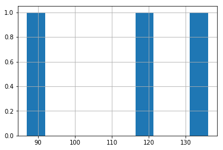

```python
# i notice there's some NaN in age colmns,why is that? , i will get to that later

survivals_per_class = survivals.groupby(['Pclass']).count()

print(survivals_per_class['Survived'])

survivals_per_class['Survived'].hist()

#looks like the lower class made it,and the rich of course , but why??
```

most important factors are : cabin , sex , sibsp , age and parch

after dealing with Pclass , like you can guess the rich people who were on top of the titanic made it , or are more likely to made it , i'm going to atack the sex column now

```python
titanic.Sex.isnull().sum() #no missing data great!
```

```
0
```

```python
men = titanic[titanic['Sex'] == 'male']

women = titanic[titanic['Sex'] == 'female']

men['Sex'].count() , women['Sex'].count()


#just to see the balance between the sexes
```

```
(577, 314)
```

looks like 577 were men and 314 were females aboard , but what about childrens??? old people ???

```python
survivals_by_sex = survivals.groupby(['Sex']).count()

survivals_by_sex
```

| Sex | PassengerId | Survived | Pclass | Name | Age | SibSp | Parch | Ticket | Fare | Cabin | Embarked |
| --- | --- | --- | --- | --- | --- | --- | --- | --- | --- | --- | --- |
| female | 233 | 233 | 233 | 233 | 197 | 233 | 233 | 233 | 233 | 91 | 231 |
| male | 109 | 109 | 109 | 109 | 93 | 109 | 109 | 109 | 109 | 45 | 109 |

```python
titanic.Cabin.isnull().sum() # i will leave this factor later
```

```
687
```

233 females for 109 men, sound right to me

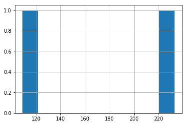

```python
survivals_by_sex['Survived'].hist()
```

```python
#next by age

titanic.Age.isnull().sum()

#looks like we do have some missing data
```

```
177
```

## for this problem i don't know how should i handle this , i can work with just the existing data but that would be not correct so, this what i will do:

**i noticed that NaNs has a relation with sibsp and parch columns**:

1- people with parch and sibSp must be old enough

2- people with parch and no sibSp will be considered as kids (travelling with nanny)

3- people with no parch and sibSp (husband and wife) or brothers , sisters

4- people with no parch and no sibSp this, were alone

**first i will handle the parch & sibsp columns**

```python
print(survivals.Parch.isnull().sum()) #no missing data

print(survivals.SibSp.isnull().sum()) #no missing data
```

```
0
0
```

```python
survival_by_familly = survivals.groupby(['SibSp','Parch']).count()

survival_by_familly
```

| SibSp | Parch | PassengerId | Survived | Pclass | Name | Sex | Age | Ticket | Fare | Cabin | Embarked |
| --- | --- | --- | --- | --- | --- | --- | --- | --- | --- | --- | --- |
| 0 | 0 | 163 | 163 | 163 | 163 | 163 | 130 | 163 | 163 | 55 | 161 |
|  | 1 | 25 | 25 | 25 | 25 | 25 | 24 | 25 | 25 | 14 | 25 |
|  | 2 | 21 | 21 | 21 | 21 | 21 | 20 | 21 | 21 | 8 | 21 |
|  | 3 | 1 | 1 | 1 | 1 | 1 | 1 | 1 | 1 | 0 | 1 |
| 1 | 0 | 64 | 64 | 64 | 64 | 64 | 52 | 64 | 64 | 35 | 64 |
|  | 1 | 34 | 34 | 34 | 34 | 34 | 31 | 34 | 34 | 12 | 34 |
|  | 2 | 12 | 12 | 12 | 12 | 12 | 12 | 12 | 12 | 5 | 12 |
|  | 3 | 1 | 1 | 1 | 1 | 1 | 1 | 1 | 1 | 0 | 1 |
|  | 5 | 1 | 1 | 1 | 1 | 1 | 1 | 1 | 1 | 0 | 1 |
| 2 | 0 | 4 | 4 | 4 | 4 | 4 | 2 | 4 | 4 | 1 | 4 |
|  | 1 | 6 | 6 | 6 | 6 | 6 | 6 | 6 | 6 | 2 | 6 |
|  | 2 | 2 | 2 | 2 | 2 | 2 | 2 | 2 | 2 | 2 | 2 |
|  | 3 | 1 | 1 | 1 | 1 | 1 | 1 | 1 | 1 | 0 | 1 |
| 3 | 0 | 2 | 2 | 2 | 2 | 2 | 2 | 2 | 2 | 0 | 2 |
|  | 2 | 2 | 2 | 2 | 2 | 2 | 2 | 2 | 2 | 2 | 2 |
| 4 | 2 | 3 | 3 | 3 | 3 | 3 | 3 | 3 | 3 | 0 | 3 |

```python
#ok , let's fill the data in age column based on my guess

a = survival_by_familly.loc[(0,[0,1,2,3]),'Survived']
b = survival_by_familly.loc[(1,[0,1,2,3,5]),'Survived']
c = survival_by_familly.loc[(2,[0,1,2,3]),'Survived']
d = survival_by_familly.loc[(3,[0,2]),'Survived']
e = survival_by_familly.loc[(4,2),'Survived']

print('survivals from a: ', a.sum() )
print('survivals from b: ', b.sum() )
print('survivals from c: ', c.sum() )
print('survivals from d: ', d.sum() )
print('survivals from e: ', e.sum() )
```

```
survivals from a:  210
survivals from b:  112
survivals from c:  13
survivals from d:  4
survivals from e:  3
```

**'b' and 'c' huband and wife or mother and father if sibsp = 1 and parch >= 1 , also made it , obivously saving the women and children first**

**the rest were either big famillies who tried to save everybody and failed or the men who risked their lives for their famillies (women & children fisrt)**

keep in mind the crew is totally ignored in this data set

```python
survivals.loc[((survivals.Name.str.contains('Miss')) & (survivals.Age.isnull())) , 'Age' ] = 23
```

```python
survivals.loc[((survivals.Name.str.contains('Mr','Mrs')) & (survivals.Age.isnull())) , 'Age'] = 35
```

```python
survivals.Age.isnull().sum() # only 2 remaining
```

```
2
```

```python
survivals[survivals['Age'].isna()]
```

|  | PassengerId | Survived | Pclass | Name | Sex | Age | SibSp | Parch | Ticket | Fare | Cabin | Embarked |
| --- | --- | --- | --- | --- | --- | --- | --- | --- | --- | --- | --- | --- |
| 65 | 66 | 1 | 3 | Moubarek, Master. Gerios | male | NaN | 1 | 1 | 2661 | 15.2458 | NaN | C |
| 709 | 710 | 1 | 3 | Moubarek, Master. Halim Gonios ("William George") | male | NaN | 1 | 1 | 2661 | 15.2458 | NaN | C |

```python
#looks like a duplicate , i'm just gonna drop one of them

survivals.loc[65, 'Age'] = 50
```

```python
survivals = survivals.drop([709])
```

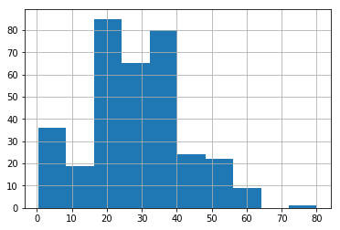

```python
survivals.Age.hist()
```

```python
survivals.Fare.isnull().sum()  #ok ! , great
```

```
0
```

# ok , after dealing with age column , the last factor is the Cabin column , historically we all know how the titanic went down , the people in the cabins in front were more likely not to survive , so

```python
survivals.Cabin.isnull().sum() # a lot of missing data
```

```
205
```

sometimes the inplace in fillna( inplace = true) argument does not work , cause pandas consider the below code as : *SettingWithCopyWaring* , so do this instade

my theory is going back to the relation between parch and sibsp , also the name column could be usefull

simply husband & wife most likely were on the same cabin

```python
survivals.loc[((survivals.Cabin.isnull()) & (survivals.Name.str.contains('Mrs , Mr'))) , 'Cabin'] = 'same one as sib'
```

```python
survivals.loc[survivals.Cabin.isnull()] = 'unknown cabin'
```

```python
#ok ,, this is just a data engineering project  but i think the data is fanally ready for ML model
```